# Understanding Joe Perry’s code on Linear Regression Quality Assurance

Author

Shazmeen Maroof

## Pipeline Configuration and Model Summary

This section shows the pipeline configuration used in generating this report. The convergence threshold determines when the model is considered to have finished training, and theta_0 and theta_1 are the regression model parameters, namely the y-intercept and gradient, respectively. The value of convergane threshold has been set to 1e-06. Learning rate has been set as 0.001. The values of theta_0 and theta_1 are set to 0. Below we see the sumary output of regression analysis.

```
                            OLS Regression Results
==============================================================================
Dep. Variable:                hdlngth   R-squared:                       0.505
Model:                            OLS   Adj. R-squared:                  0.500
Method:                 Least Squares   F-statistic:                     104.2
Date:                Mon, 20 Feb 2023   Prob (F-statistic):           2.84e-17
Time:                        08:24:29   Log-Likelihood:                -242.92
No. Observations:                 104   AIC:                             489.8
Df Residuals:                     102   BIC:                             495.1
Df Model:                           1
Covariance Type:            nonrobust
==============================================================================
                 coef    std err          t      P>|t|      [0.025      0.975]
------------------------------------------------------------------------------
const         46.1954      4.554     10.145      0.000      37.163      55.227
skullw         0.8158      0.080     10.207      0.000       0.657       0.974
==============================================================================
Omnibus:                        9.686   Durbin-Watson:                   1.779
Prob(Omnibus):                  0.008   Jarque-Bera (JB):               11.780
Skew:                          -0.509   Prob(JB):                      0.00277
Kurtosis:                       4.297   Cond. No.                     1.05e+03
==============================================================================

Warnings:
[1] Standard Errors assume that the covariance matrix of the errors is correctly specified.
[2] The condition number is large, 1.05e+03. This might indicate that there are
strong multicollinearity or other numerical problems.
```

## Model Performance

The model has a coefficient of determination (R^2) of 0.50527. Below we see the best fit line of the model plotted alongside the data.

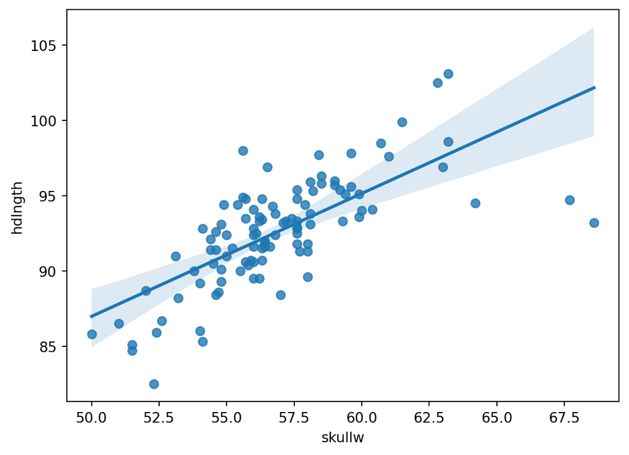

One of the assumptions of linear regression is that the errors are normally distributed. We may visually check this by plotting the errors/residuals against the model’s predicted y-values. We want the residuals to be randomly distributed about zero, regardless of the size of the fitted/predicted values. Structure in the residual plot can reveal a violation of linear regression assumptions.

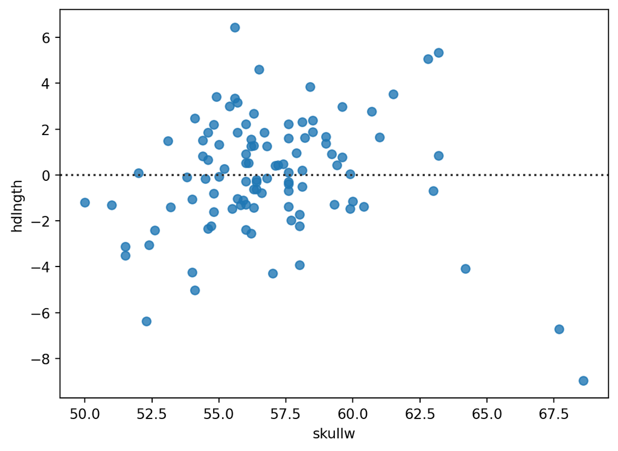

A QQ plot also allows us to assess whether the residuals are likely to have come from a normal distribution.

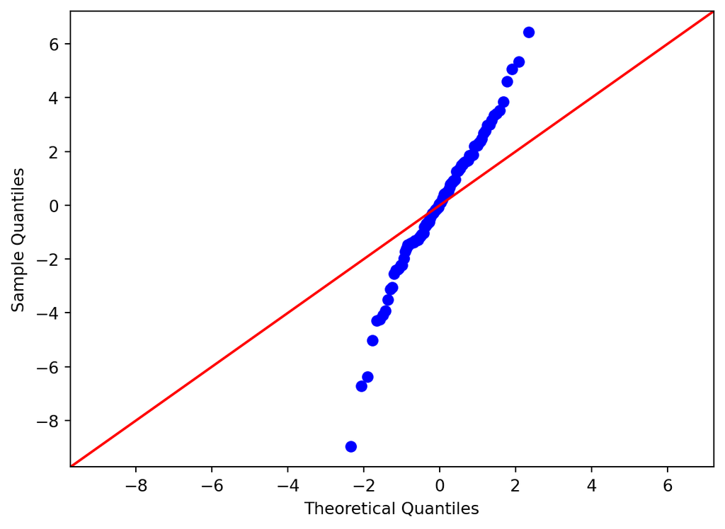

[figure not shown]

```
statistics=0.940, p=0.000
```